# 英超进球数探索分析

### (2)正交旋转的因子分析

```r
fa = fa(data4, nfactors = 4, rotate = "varimax", fm = "gls", scores = TRUE)
fa
```

```
## Factor Analysis using method =  gls
## Call: fa(r = data4, nfactors = 4, rotate = "varimax", scores = TRUE,
##     fm = "gls")
## Standardized loadings (pattern matrix) based upon correlation matrix
##                 GLS2  GLS1  GLS3  GLS4    h2    u2 com
## 年龄            0.06 -0.01  0.20  0.14 0.062 0.938 2.0
## 出场            0.72  0.25  0.18  0.26 0.675 0.325 1.7
## 首发            0.80  0.20  0.28  0.22 0.807 0.193 1.5
## 出场时间        0.84  0.26  0.29  0.22 0.915 0.085 1.6
## 进球            0.05  0.76 -0.10  0.60 0.948 0.052 1.9
## 助攻            0.25  0.63 -0.23  0.00 0.516 0.484 1.6
## 传球            0.81  0.16  0.07 -0.03 0.682 0.318 1.1
## 过人            0.30  0.50 -0.37  0.08 0.486 0.514 2.6
## 抢断            0.84 -0.11  0.06 -0.17 0.746 0.254 1.1
## 越位           -0.04  0.45 -0.13  0.63 0.618 0.382 1.9
## 犯规            0.64  0.04 -0.04  0.46 0.620 0.380 1.8
## 射门            0.21  0.69 -0.22  0.56 0.881 0.119 2.4
## 射正            0.11  0.71 -0.19  0.60 0.916 0.084 2.2
## 射门成功率     -0.09  0.23  0.21  0.24 0.165 0.835 3.3
## 头球进球        0.01  0.14  0.22  0.79 0.685 0.315 1.2
## 左脚进球       -0.08  0.89  0.00  0.03 0.805 0.195 1.0
## 右脚进球        0.14  0.47 -0.24  0.63 0.691 0.309 2.3
## 直接任意球进球  0.09  0.49 -0.03  0.00 0.248 0.752 1.1
## 赢得点球机会   -0.01  0.60 -0.04  0.24 0.422 0.578 1.3
## 拦截            0.77 -0.14  0.33 -0.21 0.771 0.229 1.6
## 解围            0.30 -0.19  0.92 -0.03 0.963 0.037 1.3
## 头球解围        0.26 -0.17  0.92  0.01 0.937 0.063 1.2
## 后场解围        0.26 -0.18  0.92 -0.05 0.948 0.052 1.3
## 头球争顶成功    0.18 -0.10  0.43  0.62 0.610 0.390 2.0
##
##                       GLS2 GLS1 GLS3 GLS4
## SS loadings           4.75 4.45 3.51 3.41
## Proportion Var        0.20 0.19 0.15 0.14
## Cumulative Var        0.20 0.38 0.53 0.67
## Proportion Explained  0.29 0.28 0.22 0.21
## Cumulative Proportion 0.29 0.57 0.79 1.00
##
## Mean item complexity =  1.7
## Test of the hypothesis that 4 factors are sufficient.
##
## The degrees of freedom for the null model are  276  and the objective function was  34.52 with Chi Square of  5391.46
## The degrees of freedom for the model are 186  and the objective function was  12.17
##
## The root mean square of the residuals (RMSR) is  0.05
## The df corrected root mean square of the residuals is  0.06
##
## The harmonic number of observations is  166 with the empirical chi square  235.75  with prob <  0.0079
## The total number of observations was  166  with Likelihood Chi Square =  1868.76  with prob <  2.8e-275
##
## Tucker Lewis Index of factoring reliability =  0.503
## RMSEA index =  0.244  and the 90 % confidence intervals are  0.225 0.244
## BIC =  917.93
## Fit based upon off diagonal values = 0.98
## Measures of factor score adequacy
##                                                   GLS2 GLS1 GLS3 GLS4
## Correlation of (regression) scores with factors   0.98 0.98 1.00 0.98
## Multiple R square of scores with factors          0.97 0.96 0.99 0.95
## Minimum correlation of possible factor scores     0.93 0.92 0.98 0.91
```

从上面正交旋转的广义最小二乘法进行因子分析的结果来看，前四个因子已经能够解释总方差的65%左右。利用去四个因子得分进行回归分析是比较可靠的。

```r
head(fa$scores)  #显示因子得分
```

```
##             GLS2        GLS1       GLS3        GLS4
## [1,]  0.79044285 -0.39323608  2.9562176  0.17653765
## [2,]  0.91524750  0.45115338 -0.3971337  1.33713159
## [3,] -0.64728997 -0.41097267  1.5912522 -0.04431517
## [4,]  0.06016711 -0.22469346  2.9842592 -0.47163125
## [5,] -0.37822855  0.05104589  0.2477124  1.84704438
## [6,] -0.78316174 -0.99812477 -0.3623535  1.17064737
```

```r
fa$loadings  #因子载荷
```

```
##
## Loadings:
##                GLS2   GLS1   GLS3   GLS4
## 年龄                          0.198  0.139
## 出场            0.718  0.245  0.176  0.263
## 首发            0.802  0.199  0.278  0.217
## 出场时间        0.844  0.262  0.289  0.222
## 进球                   0.760 -0.104  0.597
## 助攻            0.253  0.631 -0.233
## 传球            0.806  0.160
## 过人            0.305  0.503 -0.366
## 抢断            0.839 -0.110        -0.166
## 越位                   0.453 -0.134  0.627
## 犯规            0.638                0.459
## 射门            0.211  0.691 -0.221  0.556
## 射正            0.115  0.713 -0.187  0.600
## 射门成功率             0.233  0.211  0.239
## 头球进球               0.136  0.218  0.787
## 左脚进球               0.893
## 右脚进球        0.137  0.471 -0.244  0.625
## 直接任意球进球         0.490
## 赢得点球机会           0.601         0.242
## 拦截            0.774 -0.143  0.328 -0.208
## 解围            0.295 -0.186  0.916
## 头球解围        0.259 -0.172  0.916
## 后场解围        0.265 -0.184  0.917
## 头球争顶成功    0.178 -0.104  0.427  0.621
##
##                 GLS2  GLS1  GLS3  GLS4
## SS loadings    4.750 4.452 3.507 3.408
## Proportion Var 0.198 0.185 0.146 0.142
## Cumulative Var 0.198 0.383 0.530 0.672
```

### (3)因子回归分析

以y下一赛季进球数为因变量，其他所有因子得分为自变量进行线性回归分析。

```r
scores <- fa$scores  #提取因子得分
redata <- cbind(scores, data3["下一年进球"])
names(redata)[5] <- "y"
redata <- as.data.frame(redata)  #合成矩阵进行回归分析
lm.reg <- lm(y ~ ., data = redata)
summary(lm.reg)
```

```
##
## Call:
## lm(formula = y ~ ., data = redata)
##
## Residuals:
##     Min      1Q  Median      3Q     Max
## -7.2639 -1.8081 -0.3312  0.9753 13.7330
##
## Coefficients:
##             Estimate Std. Error t value Pr(>|t|)
## (Intercept)   3.0120     0.2750  10.952  < 2e-16 ***
## GLS2          0.1201     0.2807   0.428  0.66937
## GLS1          2.7955     0.2816   9.926  < 2e-16 ***
## GLS3         -0.9184     0.2772  -3.314  0.00114 **
## GLS4          1.1561     0.2826   4.091 6.78e-05 ***
## ---
## Signif. codes:  0 '***' 0.001 '**' 0.01 '*' 0.05 '.' 0.1 ' ' 1
##
## Residual standard error: 3.543 on 161 degrees of freedom
## Multiple R-squared:  0.4462, Adjusted R-squared:  0.4325
## F-statistic: 32.43 on 4 and 161 DF,  p-value: < 2.2e-16
```

通过回归结果可以看到，F检验通过，说明整体的线性关系显著，p值远远小于0.05。但是t检验中，有gls2的回归系数不显著，考虑进行一次变量选择。

```r
lm.step <- step(lm.reg, direction = "both", trace = 0)  #利用逐步回归进行变量的筛选与选择
summary(lm.step)
```

```
##
## Call:
## lm(formula = y ~ GLS1 + GLS3 + GLS4, data = redata)
##
## Residuals:
##     Min      1Q  Median      3Q     Max
## -7.3885 -1.8022 -0.3262  0.9235 13.8600
##
## Coefficients:
##             Estimate Std. Error t value Pr(>|t|)
## (Intercept)   3.0120     0.2743  10.980  < 2e-16 ***
## GLS1          2.7960     0.2809   9.953  < 2e-16 ***
## GLS3         -0.9172     0.2764  -3.318  0.00112 **
## GLS4          1.1565     0.2819   4.103 6.46e-05 ***
## ---
## Signif. codes:  0 '***' 0.001 '**' 0.01 '*' 0.05 '.' 0.1 ' ' 1
##
## Residual standard error: 3.534 on 162 degrees of freedom
## Multiple R-squared:  0.4456, Adjusted R-squared:  0.4353
## F-statistic:  43.4 on 3 and 162 DF,  p-value: < 2.2e-16
```

进行一次变量选择以后，剔出了gls2变量，调整的评定系数略有提升，达到43.53%。使用上述模型可以对球员的下一季进球进行预测可靠性较高。

可以得到回归方程分别为： 下赛季进球数 = 3.0120+2.7960进攻能力-0.9172防守能力+1.1565 推进能力

## 4.主成分分析

### (1).描述性分析

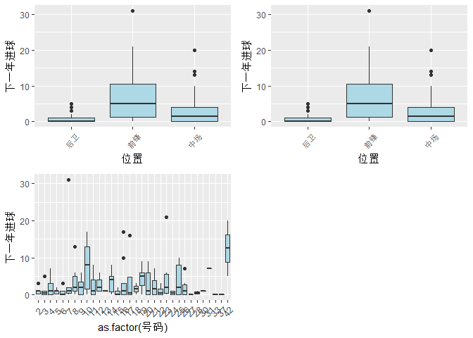

```r
# 描述性统计
vp = function(x, y) {
    viewport(layout.pos.row = x, layout.pos.col = y)
}
p1 = ggplot(data, aes(x = 位置, y = 下一年进球)) + geom_boxplot(fill = "lightblue") +
    theme(axis.text.x = element_text(angle = 45, hjust = 0.5, vjust = 0.5))
p2 = ggplot(data, aes(x = 位置, y = 下一年进球)) + geom_boxplot(fill = "lightblue") +
    theme(axis.text.x = element_text(angle = 45, hjust = 0.5, vjust = 0.5))
p3 = ggplot(data, aes(x = as.factor(号码), y = 下一年进球)) + geom_boxplot(fill = "lightblue") +
    theme(axis.text.x = element_text(angle = 45, hjust = 0.5, vjust = 0.5))
grid.newpage()
pushViewport(viewport(layout = grid.layout(2, 2)))
print(p1, vp = vp(1, 1))
print(p2, vp = vp(1, 2))
print(p3, vp = vp(2, 1))
```

### (2).主成分分析的变量处理

对部分分类变量进行onehot处理

```r
# 对分类变量进行onehot处理
data = dummy.data.frame(data, names = c("位置"), sep = "")
onedata = data[, setdiff(names(data), c("下一年进球", "头球争顶失败", "球队",
    "号码", "球员"))]
# 查看数据的基本情况
summary(onedata)
```

```
##       年龄          位置后卫         位置前锋         位置中场
##  Min.   :20.00   Min.   :0.0000   Min.   :0.0000   Min.   :0.0000
##  1st Qu.:25.00   1st Qu.:0.0000   1st Qu.:0.0000   1st Qu.:0.0000
##  Median :27.00   Median :0.0000   Median :0.0000   Median :1.0000
##  Mean   :27.49   Mean   :0.3012   Mean   :0.1807   Mean   :0.5181
##  3rd Qu.:30.00   3rd Qu.:1.0000   3rd Qu.:0.0000   3rd Qu.:1.0000
##  Max.   :40.00   Max.   :1.0000   Max.   :1.0000   Max.   :1.0000
##       出场            首发          出场时间         进球
##  Min.   : 0.00   Min.   : 0.00   Min.   :  22   Min.   : 0.000
##  1st Qu.:21.00   1st Qu.:13.25   1st Qu.:1255   1st Qu.: 1.000
##  Median :28.00   Median :24.00   Median :2136   Median : 2.000
##  Mean   :26.23   Mean   :21.84   Mean   :1969   Mean   : 3.759
##  3rd Qu.:34.00   3rd Qu.:30.75   3rd Qu.:2650   3rd Qu.: 5.000
##  Max.   :38.00   Max.   :38.00   Max.   :3420   Max.   :26.000
##       助攻             传球             过人             抢断
##  Min.   : 0.000   Min.   :   9.0   Min.   :  0.00   Min.   :  1.00
##  1st Qu.: 0.000   1st Qu.: 516.8   1st Qu.:  9.00   1st Qu.: 19.25
##  Median : 2.000   Median : 892.0   Median : 22.00   Median : 35.00
##  Mean   : 2.404   Mean   : 948.5   Mean   : 32.33   Mean   : 41.01
##  3rd Qu.: 4.000   3rd Qu.:1292.0   3rd Qu.: 47.50   3rd Qu.: 57.00
##  Max.   :12.000   Max.   :2774.0   Max.   :255.00   Max.   :146.00
##       越位             犯规            红牌             黄牌
##  Min.   : 0.000   Min.   : 0.00   Min.   :0.0000   Min.   : 0.000
##  1st Qu.: 0.000   1st Qu.:14.00   1st Qu.:0.0000   1st Qu.: 1.000
##  Median : 2.000   Median :23.00   Median :0.0000   Median : 3.000
##  Mean   : 5.651   Mean   :25.46   Mean   :0.1687   Mean   : 3.392
##  3rd Qu.: 6.000   3rd Qu.:34.75   3rd Qu.:0.0000   3rd Qu.: 5.000
##  Max.   :50.000   Max.   :82.00   Max.   :2.0000   Max.   :10.000
##       射门             射正      射门成功率         头球进球
##  Min.   :  0.00   Min.   : 0   Min.   :0.00000   Min.   :0.0000
##  1st Qu.: 14.00   1st Qu.: 3   1st Qu.:0.04348   1st Qu.:0.0000
##  Median : 23.50   Median : 8   Median :0.09281   Median :0.0000
##  Mean   : 34.98   Mean   :12   Mean   :0.10072   Mean   :0.6747
##  3rd Qu.: 52.50   3rd Qu.:16   3rd Qu.:0.14286   3rd Qu.:1.0000
##  Max.   :187.00   Max.   :72   Max.   :0.57143   Max.   :5.0000
##     左脚进球         右脚进球      直接任意球进球        点球
##  Min.   : 0.000   Min.   : 0.000   Min.   :0.0000   Min.   :0.0000
##  1st Qu.: 0.000   1st Qu.: 0.000   1st Qu.:0.0000   1st Qu.:0.0000
##  Median : 0.000   Median : 1.000   Median :0.0000   Median :0.0000
##  Mean   : 1.145   Mean   : 1.928   Mean   :0.1205   Mean   :0.3133
##  3rd Qu.: 1.000   3rd Qu.: 3.000   3rd Qu.:0.0000   3rd Qu.:0.0000
##  Max.   :18.000   Max.   :15.000   Max.   :2.0000   Max.   :5.0000
##   赢得点球机会        拦截             解围           头球解围
##  Min.   :0.000   Min.   :  1.00   Min.   :  0.00   Min.   :  0.00
##  1st Qu.:0.000   1st Qu.: 12.00   1st Qu.: 12.00   1st Qu.:  5.00
##  Median :0.000   Median : 27.50   Median : 30.00   Median : 15.00
##  Mean   :0.247   Mean   : 32.83   Mean   : 63.85   Mean   : 34.43
##  3rd Qu.:0.000   3rd Qu.: 48.00   3rd Qu.: 81.25   3rd Qu.: 43.75
##  Max.   :5.000   Max.   :139.00   Max.   :381.00   Max.   :195.00
##     后场解围       头球争顶成功        乌龙球
##  Min.   :  0.00   Min.   :  0.00   Min.   :0.0000
##  1st Qu.:  4.25   1st Qu.:  8.00   1st Qu.:0.0000
##  Median : 14.00   Median : 20.50   Median :0.0000
##  Mean   : 33.97   Mean   : 36.50   Mean   :0.1205
##  3rd Qu.: 40.00   3rd Qu.: 50.75   3rd Qu.:0.0000
##  Max.   :208.00   Max.   :281.00   Max.   :2.0000
```

```r
# 查看标准差的差异
apply(onedata, 2, sd)
```

```
##           年龄       位置后卫       位置前锋       位置中场           出场
##     3.45138881     0.46016966     0.38595268     0.50118516     9.05867652
##           首发       出场时间           进球           助攻           传球
##    10.30619928   861.70587364     4.49805443     2.57959103   552.74454261
##           过人           抢断           越位           犯规           红牌
##    34.90304989    28.38180979     9.77062231    16.46211534     0.40659047
##           黄牌           射门           射正     射门成功率       头球进球
##     2.50520451    31.11580555    12.70027439     0.08758995     1.05150321
##       左脚进球       右脚进球 直接任意球进球           点球   赢得点球机会
##     2.16099040     2.85310307     0.39381861     0.93326031     0.64607671
##           拦截           解围       头球解围       后场解围   头球争顶成功
##    25.21013910    79.73209821    45.32300045    45.50649966    44.00092974
##         乌龙球
##     0.37811624
```

### (3)主成分分析

将预处理后的变量矩阵进行主成分分析如下

```r
# 对提取的onehot数据进行标准化
onedata <- scale(onedata, scale = T)
# 进行主成分分析
pca.fit <- princomp(onedata, cor = T)
# 展示主成分分析结果
summary(pca.fit)
```

```
## Importance of components:
##                           Comp.1    Comp.2    Comp.3     Comp.4     Comp.5
## Standard deviation     2.8145811 2.6021826 1.7741840 1.30559403 1.22959197
## Proportion of Variance 0.2555441 0.2184308 0.1015396 0.05498632 0.04877085
## Cumulative Proportion  0.2555441 0.4739749 0.5755145 0.63050083 0.67927168
##                            Comp.6    Comp.7     Comp.8     Comp.9
## Standard deviation     1.07018436 1.0001819 0.98947422 0.93855873
## Proportion of Variance 0.03694499 0.0322698 0.03158256 0.02841589
## Cumulative Proportion  0.71621666 0.7484865 0.78006902 0.80848491
##                           Comp.10   Comp.11    Comp.12    Comp.13
## Standard deviation     0.88042565 0.8137646 0.79128793 0.75150056
## Proportion of Variance 0.02500482 0.0213617 0.02019795 0.01821784
## Cumulative Proportion  0.83348972 0.8548514 0.87504938 0.89326722
##                          Comp.14    Comp.15    Comp.16    Comp.17
## Standard deviation     0.7326256 0.70002510 0.67338575 0.60541936
## Proportion of Variance 0.0173142 0.01580759 0.01462737 0.01182363
## Cumulative Proportion  0.9105814 0.92638901 0.94101638 0.95284001
##                           Comp.18     Comp.19     Comp.20     Comp.21
## Standard deviation     0.51628578 0.500330655 0.472724633 0.429185824
## Proportion of Variance 0.00859842 0.008075186 0.007208664 0.005941951
## Cumulative Proportion  0.96143843 0.969513614 0.976722278 0.982664229
##                            Comp.22     Comp.23     Comp.24     Comp.25
## Standard deviation     0.394347835 0.342936961 0.300371656 0.259107472
## Proportion of Variance 0.005016459 0.003793734 0.002910424 0.002165699
## Cumulative Proportion  0.987680687 0.991474421 0.994384845 0.996550544
##                            Comp.26      Comp.27      Comp.28      Comp.29
## Standard deviation     0.243306730 0.1527232103 0.1326835644 0.0808956831
## Proportion of Variance 0.001909618 0.0007523993 0.0005679009 0.0002111004
## Cumulative Proportion  0.998460163 0.9992125620 0.9997804629 0.9999915633
##                             Comp.30 Comp.31
## Standard deviation     1.617211e-02       0
## Proportion of Variance 8.436683e-06       0
## Cumulative Proportion  1.000000e+00       1
```

利用碎石图进行变量的选择

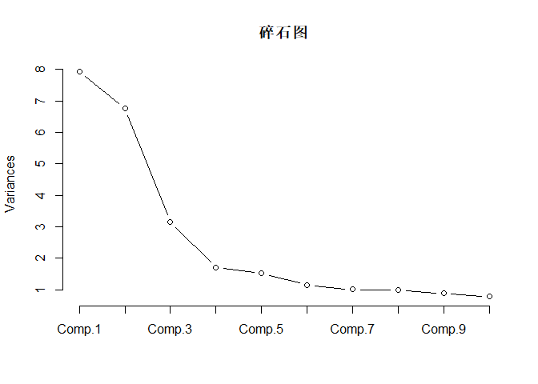

```r
# 做出碎石图
plot(pca.fit, type = "lines", main = "碎石图")
```

从碎石图中的结果，可以看到碎石图从第三个变量之后变得平稳。到前就9个主成分的方差贡献率达到了80%，因此可以取出前九个主成分当作解释变量。

```r
# 存储所有前9个主成分得分
pca_data = pca.fit$scores[, 1:9]
```

### (4)主成分回归分析

利用提取的主成分进行回归

```r
# 保留主成分以及后合成训练矩阵
train_data = data.frame(data$下一年进球, pca_data)

# 改变变量的名称
colnames(train_data)[1] = "y"
fit <- lm(y ~ ., data = train_data)
summary(fit)
```

```
##
## Call:
## lm(formula = y ~ ., data = train_data)
##
## Residuals:
##     Min      1Q  Median      3Q     Max
## -7.3158 -2.0120 -0.1629  1.3061 15.6820
##
## Coefficients:
##             Estimate Std. Error t value Pr(>|t|)
## (Intercept)  3.01205    0.27421  10.984  < 2e-16 ***
## Comp.1      -0.98229    0.09743 -10.082  < 2e-16 ***
## Comp.2       0.47400    0.10538   4.498 1.33e-05 ***
## Comp.3      -0.00663    0.15456  -0.043   0.9658
## Comp.4      -0.46243    0.21003  -2.202   0.0292 *
## Comp.5       0.40700    0.22301   1.825   0.0699 .
## Comp.6       0.30172    0.25623   1.178   0.2408
## Comp.7       0.33807    0.27416   1.233   0.2194
## Comp.8       0.48909    0.27713   1.765   0.0795 .
## Comp.9       0.16702    0.29217   0.572   0.5684
## ---
## Signif. codes:  0 '***' 0.001 '**' 0.01 '*' 0.05 '.' 0.1 ' ' 1
##
## Residual standard error: 3.533 on 156 degrees of freedom
## Multiple R-squared:  0.4665, Adjusted R-squared:  0.4357
## F-statistic: 15.16 on 9 and 156 DF,  p-value: < 2.2e-16
```

从线性回归分析的结果看，回归方程能解释46.65%的变异程度，且F的值的p值小于2.2e-16，说明方程整体的显著性水平很高。但t检验有很多变量不通过，因此进一步进行逐步回归，筛选变量。

```r
fit <- step(fit, direction = "both", trace = 0)  #利用逐步回归进行变量的筛选与选择
summary(fit)
```

```
##
## Call:
## lm(formula = y ~ Comp.1 + Comp.2 + Comp.4 + Comp.5 + Comp.8,
##     data = train_data)
##
## Residuals:
##    Min     1Q Median     3Q    Max
## -7.102 -1.901 -0.230  1.233 15.186
##
## Coefficients:
##             Estimate Std. Error t value Pr(>|t|)
## (Intercept)  3.01205    0.27356  11.011  < 2e-16 ***
## Comp.1      -0.98229    0.09719 -10.107  < 2e-16 ***
## Comp.2       0.47400    0.10513   4.509 1.25e-05 ***
## Comp.4      -0.46243    0.20953  -2.207   0.0287 *
## Comp.5       0.40700    0.22248   1.829   0.0692 .
## Comp.8       0.48909    0.27647   1.769   0.0788 .
## ---
## Signif. codes:  0 '***' 0.001 '**' 0.01 '*' 0.05 '.' 0.1 ' ' 1
##
## Residual standard error: 3.525 on 160 degrees of freedom
## Multiple R-squared:  0.4554, Adjusted R-squared:  0.4384
## F-statistic: 26.76 on 5 and 160 DF,  p-value: < 2.2e-16
```